# Eplanatory_ananlysis_slide_deck

## Prosper Loans Analysis

### Dataset Overview:

The dataset we have is about prosper loans for a bank which describes everyhing about loans of the borrowers like theire pupose or loan category and also information about the borrower itself.

## What Questions that we will Answer?

- What Category of loans is the most ordered?
- What is the most familiar months that the borrowers make loans?
- What state has the most number of loans?
- What is the most employment status that ordered a loan?
- What is the relation between Open Credit lines and both Income Range and Debit to Income Ratio?
- Income ranges of the borrowers ?

## 1. Extracting Data:

```python
import numpy as np
import pandas as pd
import matplotlib.pyplot as plt
import seaborn as sns
%matplotlib inline
```

```python
df = pd.read_csv("Modified_data.csv")
df.head()
```

|  | ListingKey | ListingNumber | ListingCreationDate | CreditGrade | Term | LoanStatus | ClosedDate | BorrowerAPR | BorrowerRate | LenderYield | ... | LP_ServiceFees | LP_CollectionFees | LP_GrossPrincipalLoss | LP_NetPrincipalLoss | LP_NonPrincipalRecoverypayments | PercentFunded | Recommendations | InvestmentFromFriendsCount | InvestmentFromFriendsAmount | Investors |
| --- | --- | --- | --- | --- | --- | --- | --- | --- | --- | --- | --- | --- | --- | --- | --- | --- | --- | --- | --- | --- | --- |
| 0 | 1021339766868145413AB3B | 193129 | 2007-08-26 19:09:29.263 | C | 36 | Completed | 2009-08-14 00:00:00.000 | 0.16516 | 0.1580 | 0.1380 | ... | -133.18 | 0.0 | 0.0 | 0.0 | 0.0 | 1.0 | 0 | 0 | 0.0 | 258 |
| 1 | 10273602499503308B223C1 | 1209647 | 2014-02-27 08:28:07.900 | NaN | 36 | Current | NaN | 0.12016 | 0.0920 | 0.0820 | ... | 0.00 | 0.0 | 0.0 | 0.0 | 0.0 | 1.0 | 0 | 0 | 0.0 | 1 |
| 2 | 0EF5356002482715299901A | 658116 | 2012-10-22 11:02:35.010 | NaN | 36 | Current | NaN | 0.12528 | 0.0974 | 0.0874 | ... | -108.01 | 0.0 | 0.0 | 0.0 | 0.0 | 1.0 | 0 | 0 | 0.0 | 158 |
| 3 | 0F023589499656230C5E3E2 | 909464 | 2013-09-14 18:38:39.097 | NaN | 36 | Current | NaN | 0.24614 | 0.2085 | 0.1985 | ... | -60.27 | 0.0 | 0.0 | 0.0 | 0.0 | 1.0 | 0 | 0 | 0.0 | 20 |
| 4 | 0F05359734824199381F61D | 1074836 | 2013-12-14 08:26:37.093 | NaN | 60 | Current | NaN | 0.15425 | 0.1314 | 0.1214 | ... | -25.33 | 0.0 | 0.0 | 0.0 | 0.0 | 1.0 | 0 | 0 | 0.0 | 1 |

5 rows × 80 columns

```python
df["ListingCreationDate"] = pd.to_datetime(df["ListingCreationDate"])
```

## 2. Assesing And Cleaning Data:

### Issues Fixed In the Data set:

- Null Values Due to some errors in handling loans specially before 2009.
- In correct Data types for several Coluns.
- There are some Columns do the same job but with different naming.
- Corrcting some vlaues.

## 3. Answering Questions:

### 3.1 Most Ordered Loans:

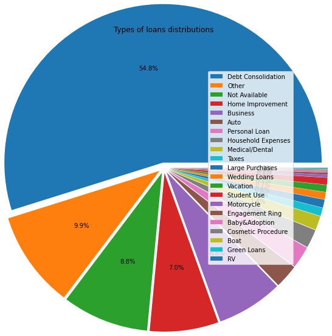

```python
plt.figure(figsize = (10,8))
plt.title("Types of loans distributions")
df["ListingCategory"].value_counts()
labels = df["ListingCategory"].value_counts().index
plt.pie(df["ListingCategory"].value_counts(), explode = [0.05]*len(labels), autopct="%.1f%%", rotatelabels = 270, labeldistance=1.1, radius = 1.5);
plt.legend(labels, loc = "right");
```

- The most loans category is debt consolidation with a percentage more that tha half of the total loans.
- We have to be more specific about the loans' purposed because the is arround 20% (9.9 for "Other" Category and 8.8 for "Not Available") and this me it hard to know their real needs so we can make a useful services for them.

### 3.2 Months' loans Distribution:

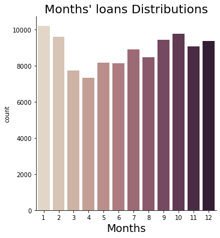

```python
df["month"]  = df["ListingCreationDate"].dt.month
sns.catplot(x= "month", kind = 'count', palette="ch:.25", data = df, legend=True, legend_out=True );
plt.title("Months' loans Distributions", fontsize = 20);
plt.xlabel("Months", fontsize = 18);
```

- Months from September to February is likely to have more loans specailly the month of Jsn, and this can be reasoned by the christmas.
- In Order to Maximize our profit we have to make it moe easy for the borrowers to have loans in the time of feasts, and also to make some sspecial offers in the mid year months, to atttract more borrowers.

### 3.3 State Distribution for the borrowers:

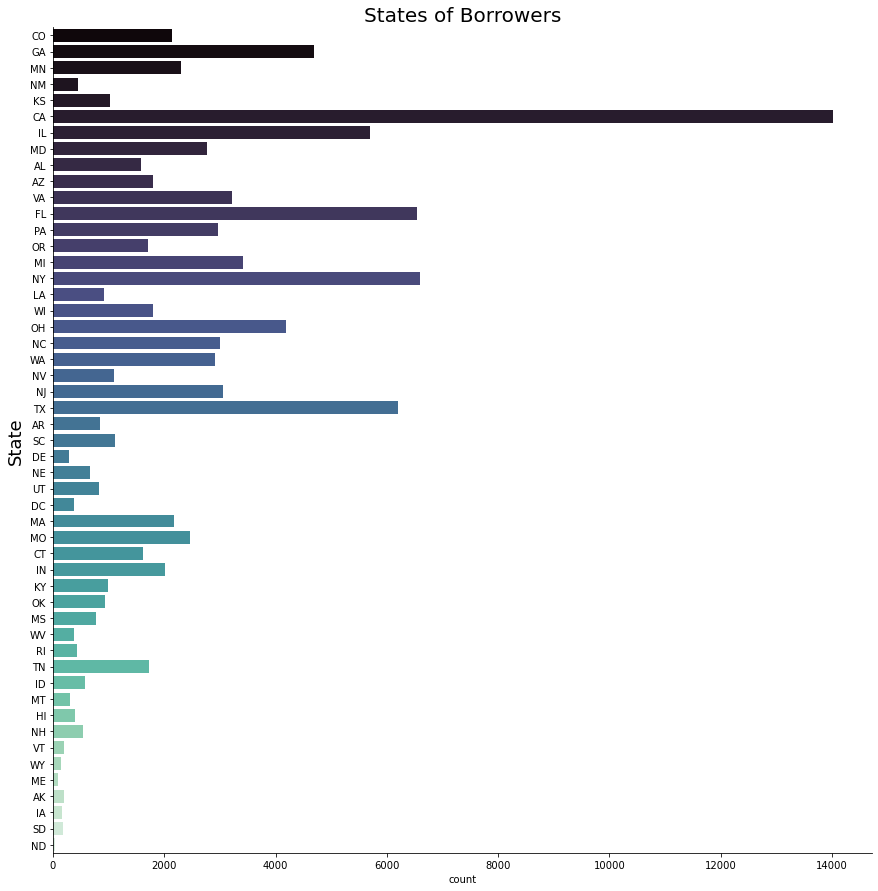

```python
sns.catplot(y= "BorrowerState",height = 12 ,kind = 'count',  palette="mako", data = df, legend=True, legend_out=True ).set(title='States of Borrowers');
plt.title("States of Borrowers", fontsize = 20);
plt.ylabel("State", fontsize = 18);
```

- We have found that California, New York, Florida and Texas are the most common cities to have loans.
- We have to make it more easy for other states to have loans for example by making ATMs Available more there specialy for the Debt Consolidation loans.

## 3.4 Relation Between Income Range and Ordering loans:

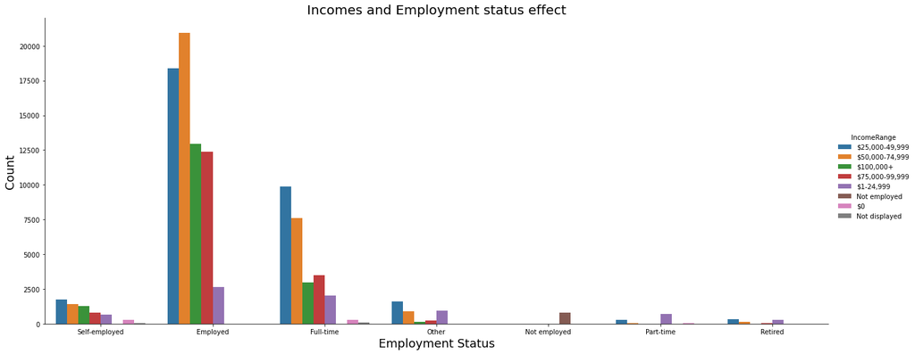

```python
sns.catplot(x="EmploymentStatus", hue="IncomeRange", kind='count', aspect=2.5,height=7, data=df);
plt.title("Incomes and Employment status effect", fontsize = 20);
plt.ylabel("Count",fontsize = 18);
plt.xlabel("Employment Status",fontsize = 18);
```

- Almost here, whatever the employement status, those whose income less than 75K are more likely to have loans

## 3.5 Relation Between The Income Range and both Debt to income ratio and Open Credit ines:

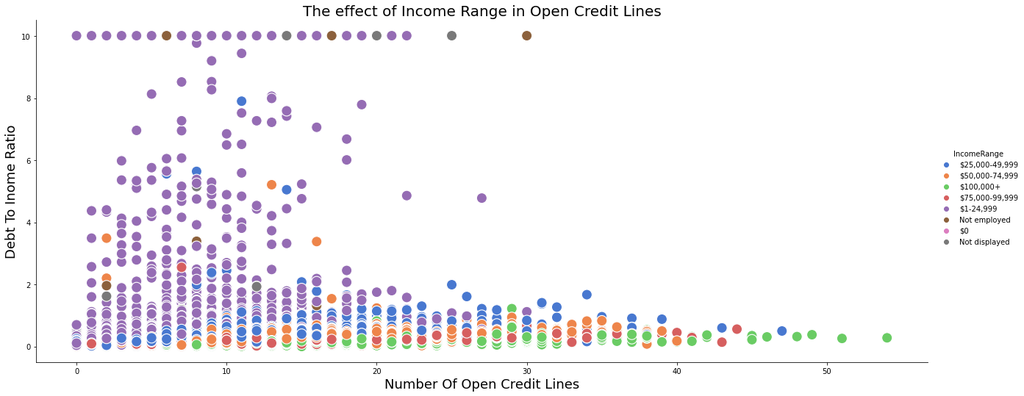

```python
sns.relplot(x="OpenCreditLines", y="DebtToIncomeRatio", hue="IncomeRange", s=200 ,aspect=2.5, palette="muted", height=7, data=df);
plt.title("The effect of Income Range in Open Credit Lines", fontsize= 20);
plt.ylabel("Debt To Inome Ratio",fontsize = 18);
plt.xlabel("Number Of Open Credit Lines",fontsize = 18);
```

- As it's Obviuos that Those Who have more Income Ranges Are more Likely to have more Open Crediti lines and has less Debt to Income Ratios.
- We have to be more precise about those who aer not employed when giving them a loans, because it appears that they have more debt to income ratios.

[figure not shown]

```python
sns.lmplot(x="OpenCreditLines", y='OpenRevolvingMonthlyPayment', hue="EmploymentStatus", aspect = 1.5,height= 10, data=df);
plt.title("Relation Between Employment Status and Open Credit Lines and ProsperScore", fontsize = 20);
plt.xlabel("Prosper Score", fontsize = 15);
plt.ylabel("Revolving Monthly Payment", fontsize = 15);
```

- there is a positive correlation between the Number of Open Credit Lines and the open revolving monthly payment.
- those who are self employed have more monthly payment but have less number of open credit lines in general.

## 4 Conclusion:

```python
!jupyter nbconvert deck.ipynb --to slides --post serve --no-input --no-prompt
```